# 使用seurat分析新冠病毒单细胞数据的转座子和基因表达情况

## 聚类分析

分为10个neighbors,按排名前40个pca成分计算

```python
sc.pp.neighbors(adata, n_neighbors=10, n_pcs=40)
```

```python
sc.tl.umap(adata)
```

在图上注释出一些基因，按基因表达量注释出颜色

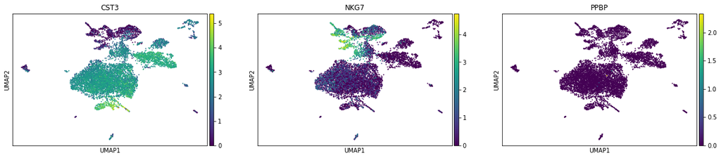

```python
sc.pl.umap(adata, color=['CST3', 'NKG7', 'PPBP'])
```

```python
sc.pl.umap(adata, color=['FTL', 'FTH1', 'CCL2'], use_raw=False)
```

[output not shown]

```python
sc.tl.leiden(adata)
```

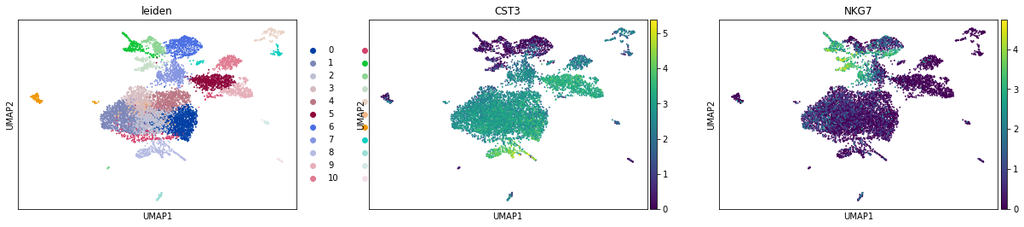

```python
sc.pl.umap(adata, color=['leiden', 'CST3', 'NKG7'])
```

各种聚类成分中的排名高的基因（t-test方法）

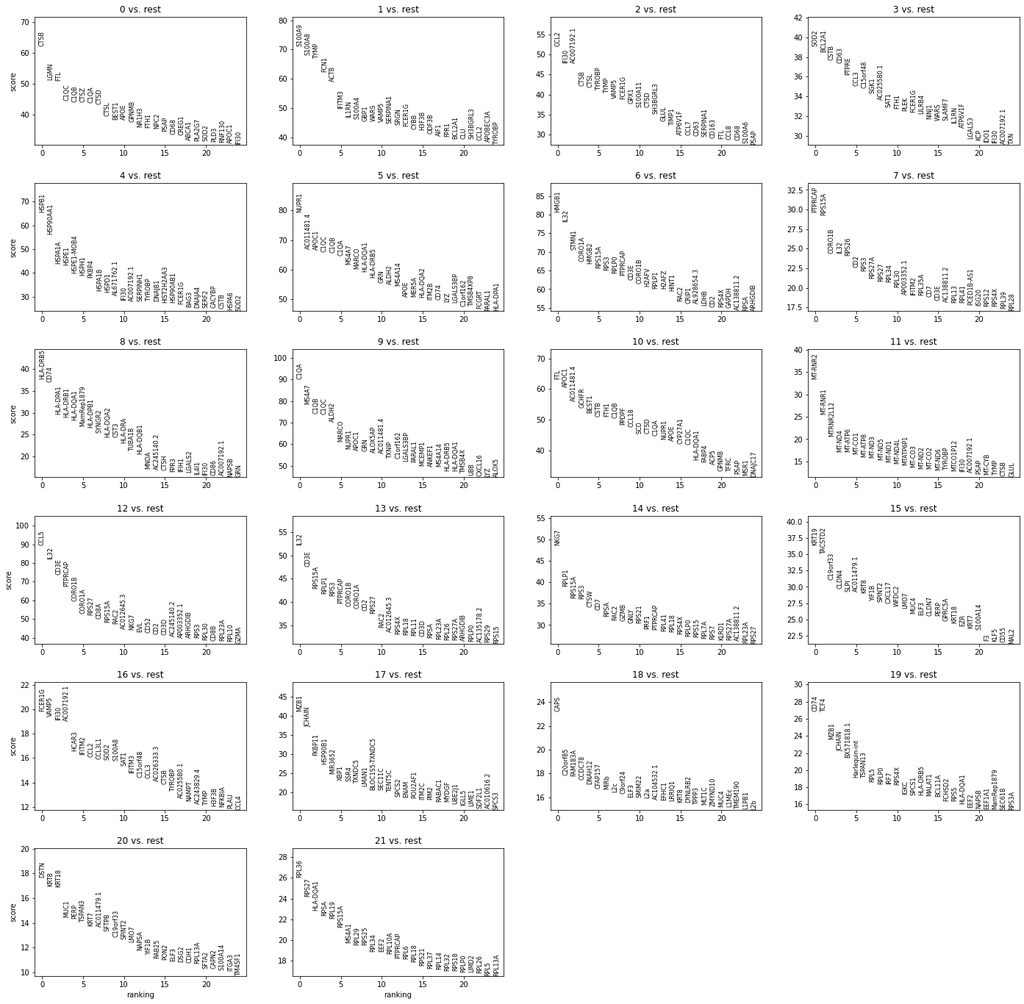

```python
sc.tl.rank_genes_groups(adata, 'leiden', method='t-test')
sc.pl.rank_genes_groups(adata, n_genes=25, sharey=False)
```

各种聚类成分中的排名高的基因（wilcoxon方法）

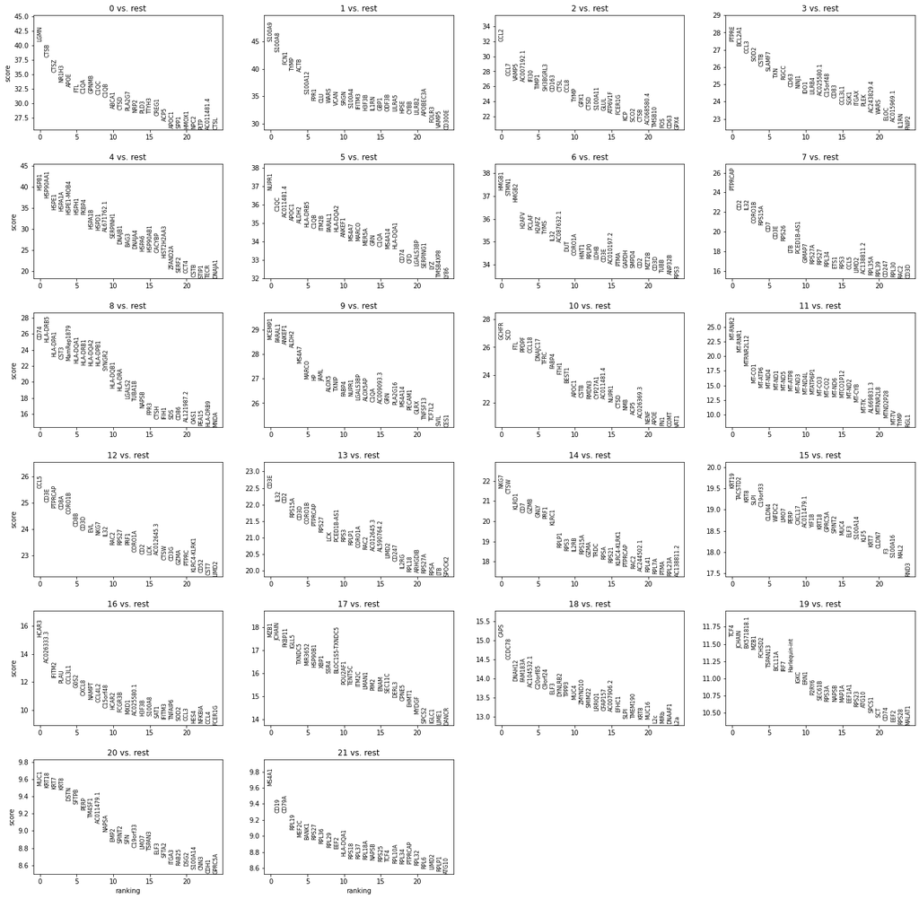

```python
sc.tl.rank_genes_groups(adata, 'leiden', method='wilcoxon')
sc.pl.rank_genes_groups(adata, n_genes=25, sharey=False)
```

小提琴图展示

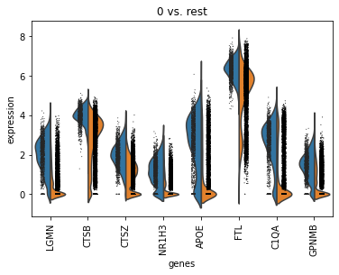

```python
sc.pl.rank_genes_groups_violin(adata, groups='0', n_genes=8)
```

跨组比较基因表达差异

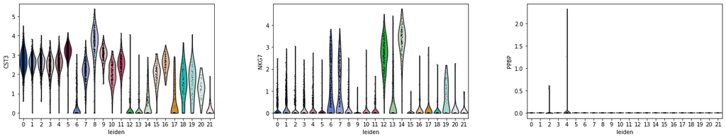

```python
sc.pl.violin(adata, ['CST3', 'NKG7', 'PPBP'], groupby='leiden')
```

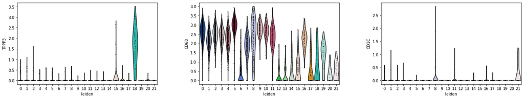

```python
sc.pl.violin(adata, ['TPPP3', 'CD68', 'CD1C'], groupby='leiden')
```

```python
adata
```

```
AnnData object with n_obs × n_vars = 8577 × 2556
    obs: 'n_genes', 'n_genes_by_counts', 'total_counts', 'total_counts_mt', 'pct_counts_mt', 'leiden'
    var: 'n_cells', 'mt', 'n_cells_by_counts', 'mean_counts', 'pct_dropout_by_counts', 'total_counts', 'highly_variable', 'means', 'dispersions', 'dispersions_norm', 'mean', 'std'
    uns: 'log1p', 'hvg', 'pca', 'neighbors', 'umap', 'leiden', 'leiden_colors', 'rank_genes_groups'
    obsm: 'X_pca', 'X_umap'
    varm: 'PCs'
    obsp: 'distances', 'connectivities'
```

## 细胞类型注释

```python
marker_genes = ['AGER','SFTPC','SCGB3A2','TPPP3','KRT5', 'FCGR3A','TREM2','KRT18', #上皮系细胞
                'CD68','FCN1','CD1C','TPSB2','CD14','MARCO','CXCR2','CLEC9A','IL3RA', #树突细胞
                'CD3D','CD8A','KLRF1',  #T/NK细胞
                'CD79A','IGHG4','MS4A1',  #B细胞
                'VWF','DCN']
```

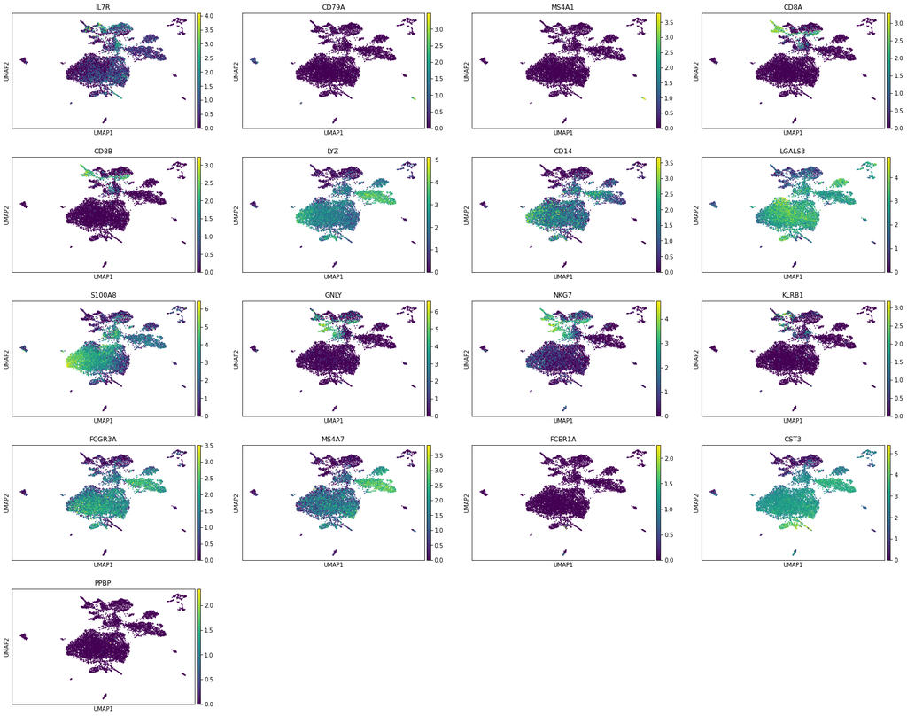

```python
sc.pl.umap(adata, color=['IL7R', 'CD79A', 'MS4A1', 'CD8A', 'CD8B', 'LYZ', 'CD14',
                'LGALS3', 'S100A8', 'GNLY', 'NKG7', 'KLRB1',
                'FCGR3A', 'MS4A7', 'FCER1A', 'CST3', 'PPBP'])
```

给这些细胞类型做注释

```python
new_cluster_names = [
    'CD4 T', 'CD14 Monocytes',
    'B', 'CD8 T',
    'NK', 'FCGR3A Monocytes',
    'Dendritic', 'Megakaryocytes',
    'AAA1','AAA2',
    'AAA3','AAA4','AAA5']
adata.rename_categories('leiden', new_cluster_names)
```

```python
sc.pl.umap(adata, color='leiden', legend_loc='on data', title='', frameon=False, save='.pdf')
```

[output not shown]

标注细胞类型后可视化标记基因

```python
sc.pl.dotplot(adata, marker_genes, groupby='leiden');
```

[output not shown]

```python
sc.pl.stacked_violin(adata, marker_genes, groupby='leiden', rotation=90); #小提琴图
```

[output not shown]

adata #检查adata累积了哪些特征类型注释

### 文献引用

1. Bedford, J. et al. COVID-19: towards controlling of a pandemic. Lancet 395, 1015‒1018 (2020).
2. Fu, L. et al. Clinical characteristics of coronavirus disease 2019 (COVID- 19) in China: a systematic review and meta-analysis. J. Infect. 80, 656‒ 665 (2020).
3. John Hopkins University. COVID-19 map. Johns Hopkins Coronavirus Resource Center. https://coronavirus.jhu.edu/map.html (2020).
4. Chen, N. et al. Epidemiological and clinical characteristics of 99 cases of 2019 novel coronavirus pneumonia in Wuhan, China: a descriptive study. Lancet 395, 507‒513 (2020).
5. Zhu, N. et al. A novel coronavirus from patients with pneumonia in China, 2019. N. Engl. J. Med. 382, 727‒733 (2020).
6. J. Huang et al., Recurrence of SARS-CoV-2 PCR positivity in COVID-19 patients: A single center experience and potential implications. medRxiv [Preprint] (2020). https:// doi.org/10.1101/2020.05.06.20089573 (Accessed 6 June 2020).
7. B. Yuan et al., Recurrence of positive SARS-CoV-2 viral RNA in recovered COVID-19 patients during medical isolation observation. Sci. Rep. 10, 11887 (2020).
8. P. V’Kovski, A. Kratzel, S. Steiner, H. Stalder, V. Thiel, Coronavirus biology and rep- lication: Implications for SARS-CoV-2. Nat. Rev. Microbiol. 19, 155‒170 (2021).
9. L. Alanagreh, F. Alzoughool, M. Atoum, The human coronavirus disease COVID-19: Its origin, characteristics, and insights into potential drugs and its mechanisms. Patho- gens 9, 331 (2020).
10. E. de Wit, N. van Doremalen, D. Falzarano, V. J. Munster, SARS and MERS: Recent insights into emerging coronaviruses. Nat. Rev. Microbiol. 14, 523‒534 (2016).
11. A. R. Fehr, S. Perlman, Coronaviruses: An overview of their replication and patho- genesis. Methods Mol. Biol. 1282, 1‒23 (2015).
12. Zhang L, Richards A, Barrasa MI, Hughes SH, Young RA, Jaenisch R. Reverse-transcribed SARS-CoV-2 RNA can integrate into the genome of cultured human cells and can be expressed in patient-derived tissues. Proc Natl Acad Sci U S A. 2021;118(21):e2105968118. doi:10.1073/pnas.2105968118
13. Rajoriya, N., et al., How viral genetic variants and genotypes influence disease and treatment outcome of chronic hepatitis B. Time for an individualised approach? J Hepatol, 2017. *67*(6): p. 1281-1297.